# Tpc_9

Diogo Alexandre Alonso De Freitas

2022-10-29

##### Enunciado

> Num inquérito sobre óculos de sol foram colocadas várias questões aos inquiridos. Para além de características sociodemográficas (sexo, idade e nível de educação), perguntou-se o tipo de óculos de sol que possuíam, quando tinham sido adquiridos, onde tinham sido adquiridos, quanto tinham custado e se eram da marca SoleMio(SM/RB). Para este TPC, irão apenas analisar duas questões: 1. O “estilo dos óculos de sol” – variável type; e, 2. a questão “are_RB”, que indica se os óculos são ou não da marca SoleMio Pretende-se saber se existe associação entre o estilo dos óculos de sol e o facto de serem da marca RB.

```r
def <- readRDS("Estudo_Oculos_Sol.rds")
def
```

| nquest | sex | age | educ | type | when_bought | where_bought | cost | are_RB | nb_own | Pub.Mk | Quality | Ergonomy | Price | Style | Will_buy_RB |
| --- | --- | --- | --- | --- | --- | --- | --- | --- | --- | --- | --- | --- | --- | --- | --- |
| 1 | Male | 38 | Tertiary | Sport style | 2+ years | Optical shop | 200EUR-300EUR | No | 1 | 7.510000 | 7.499758 | 8.447343 | 7.447002 | 8.085599 | Yes |
| 2 | Male | 37 | Tertiary | Classic | 2+ years | Optical shop | 200EUR-300EUR | Yes | 2 | 5.802424 | 8.754736 | 5.557159 | 5.712262 | 7.734740 | Yes |
| 3 | Male | 33 | Tertiary | Classic | Last year | Optical shop | 100EUR-200EUR | No | 1 | 4.756021 | 8.419108 | 7.771410 | 8.305965 | 7.563463 | Maybe |
| 4 | Female | 25 | Profissional | Sport style | Last year | Optical shop | At least 300EUR | No | 3 | 0.910000 | 8.348551 | 8.163167 | 5.792254 | 9.000000 | Yes |
| 5 | Female | 34 | Secondary | Modern | This year | Optical shop | 100EUR-200EUR | No | 3 | 4.661110 | 8.212571 | 6.832928 | 7.942378 | 9.466660 | No |
| 12 | Female | 43 | Profissional | Classic | 2+ years | Optical shop | 100EUR-200EUR | No | 1 | 4.854772 | 8.178145 | 6.116864 | 7.343421 | 8.366720 | NA |
| 13 | Male | 20 | Secondary | Sport style | Last year | Sports shop | Less than 100EUR | No | 1 | 5.804163 | 7.711914 | 6.019403 | 7.377320 | 7.283751 | NA |
| 14 | Male | 22 | Tertiary | Classic | This year | Optical shop | 200EUR-300EUR | No | 3 | 8.000000 | 8.320000 | 7.159109 | 7.000000 | 8.118014 | Maybe |
| 15 | Male | 23 | Profissional | Classic | Last year | Street vendor | Less than 100EUR | No | 1 | 6.900000 | 6.926048 | 6.333070 | 7.719045 | 8.496201 | Maybe |
| 16 | Female | 24 | Tertiary | Modern | This year | Optical shop | 200EUR-300EUR | No | 2 | 5.699232 | 8.456763 | 6.650992 | 6.653646 | 8.243380 | Maybe |

[output cut: 630 more lines]

[output not shown]

#### 1º Passo - Construir a tabela de contingência com as frequências absolutas, com o estilo em linha e a marca em coluna; adicionar as margens à tabela

```r
tab1 <- table(def$type, def$are_RB)
tab1_sum <- addmargins(tab1, FUN = sum)
```

```
## Margins computed over dimensions
## in the following order:
## 1:
## 2:
```

```r
knitr::kable(tab1_sum,format="markdown",digits=3)
```

|  | No | Yes | sum |
| --- | --- | --- | --- |
| Classic | 161 | 93 | 254 |
| Futuristic | 23 | 2 | 25 |
| Modern | 267 | 50 | 317 |
| Sport style | 37 | 7 | 44 |
| sum | 488 | 152 | 640 |

```r
tab1_prop <- prop.table(tab1) # freq relativas
tab1_propsum <- addmargins(tab1_prop, FUN = sum)
```

```
## Margins computed over dimensions
## in the following order:
## 1:
## 2:
```

```r
knitr::kable(tab1_propsum,format="markdown",digits=3)
```

|  | No | Yes | sum |
| --- | --- | --- | --- |
| Classic | 0.252 | 0.145 | 0.397 |
| Futuristic | 0.036 | 0.003 | 0.039 |
| Modern | 0.417 | 0.078 | 0.495 |
| Sport style | 0.058 | 0.011 | 0.069 |
| sum | 0.762 | 0.238 | 1.000 |

#### 3º Passo - Representar graficamente a informação

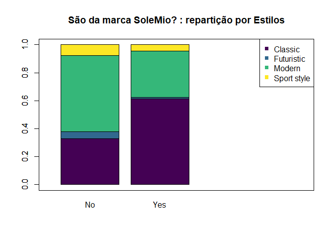

#### 4º Passo - Definir as hipóteses em teste e identificar a estatística de teste

> - X -> O estilo dos óculos de sol (Classic, Futuristic, Modern, Sport style)
> - Y -> São da marca SoleMio ? (Sim ou Não)

*Hipóteses em teste*

> - H0 -> O estilo dos óculos de sol é independente da marca SoleMio
> - H1 -> Existe relacionamento emtre o estilo de óclos e a marca SoleMio

*Ou, Teoricamente:*

$$H0: \forall(i,j) \ \in \ \{1:r\} \ \times \ \{1:c\}:P_{ij} = P_{i.}
\times P_{.j}$$
$$H1: \exists(i,j) \ \in \ \{1:r\} \ \times \ \{1:c\}:P_{ij} \not = P_{i.}
\times P_{.j}$$

*Estatística de teste*

$$ET = \sum_{i=1}^{r} \sum_{j=1}^{c} \frac {(o_{ij} - e_{ij})^2}{e_{ij}}
\sim X^2_{(r-1)(c-1)} = \sum_{i=1}^{4} \sum_{j=1}^{2} \frac {(o_{ij} -
e_{ij})^2}{e_{ij}} \sim X^2_{(4-1)(2-1)}$$

> Sendo ambas variáveis fatores, o estudo do relacionamento entre elas será feito através da análise do respetivo cruzamento (tabela de contingência), com a subsequente aplicação do teste Qui-quadrado de Pearson.

#### 5º Passo - Obter os resultados do teste

```r
teste <- chisq.test(tab1)
teste
```

```
##
##  Pearson's Chi-squared test
##
## data:  tab1
## X-squared = 39.268, df = 3, p-value = 1.523e-08
```

> Do teste é possível concluir que existe relacionamento entre as variáveis (porque o p-value apresentado é inferior ao nível de significância de referência $\alpha$), sendo necessário estudar o padrão de relacionamento. Isto significa que existem divergências significativas entre as frequências observadas e as frequências esperadas (ou seja, o que esperaríamos observar numa situação de independência). Para ter uma ideia inicial destas divergências podemos observar a tabela das frequências esperadas.

*Tabela com Frequências esperadas*

```r
tab1_esperadas<-teste$expected
knitr::kable(addmargins(tab1_esperadas, FUN = sum),format="markdown",digits=3)
```

```
## Margins computed over dimensions
## in the following order:
## 1:
## 2:
```

|  | No | Yes | sum |
| --- | --- | --- | --- |
| Classic | 193.675 | 60.325 | 254 |
| Futuristic | 19.062 | 5.938 | 25 |
| Modern | 241.713 | 75.287 | 317 |
| Sport style | 33.550 | 10.450 | 44 |
| sum | 488.000 | 152.000 | 640 |

##### A tabela acima permite ainda verficar potenciais problemas na leitura do p-value: para que os resultados do teste sejam fiáveis (no fundo, para que a ET possa ser considerada como aproximadamente uma Qui-quadrado com os parâmetros especificados) é necessário que:

> - Não mais de 20% das células apresentem valor esperado inferior a 5
> - Todas as células apresentem valor esperado superior a 1.

##### Caso isso não aconteça, o teste é realizado de qualquer das formas, mas é incluído um warning, e convém analisarmos a tabela acima.

#### 6º Passo - Mostrar a tabela dos resíduos estandardizados e identificar as associações relevantes.

```r
knitr::kable(teste$stdres,format="markdown",digits=3)
```

|  | No | Yes |
| --- | --- | --- |
| Classic | -6.204 | 6.204 |
| Futuristic | 1.888 | -1.888 |
| Modern | 4.698 | -4.698 |
| Sport style | 1.267 | -1.267 |

> Visionando a tabela anterior, é possivel verificar que as associações mais relevantes são a da linha do “Classic” e do “Modern”.

#### 7º Passo - Escrever parágrafo final que resuma os resultados encontrados em 1-6 e responda à questão colocada: saber se existe associação entre o estilo dos óculos de sol e o facto de serem da marca RB (e de que forma)

> Podemos assim concluir que, pelo estudo realizado nas alineas anteriores, rejeitamos H0, pois, o p-value apresentado é inferior ao nível de significância de referência (visionar). Analisando o gráfico do 3º passo, com a tabla de frequência esperadas, é notório que existe uma preferência pelos óculos do tipo classico da marca SoleMio e existe um maior desgosto pelo tipo moderno da marca SoleMio